# Project Course 3

## Background

Buying and selling used smartphones used to be something that happened on a handful of online marketplace sites. But the used and refurbished phone market has grown considerably over the past decade, and a new IDC (International Data Corporation) forecast predicts that the used phone market would be worth $52.7bn by 2023 with a compound annual growth rate (CAGR) of 13.6% from 2018 to 2023. This growth can be attributed to an uptick in demand for used smartphones that offer considerable savings compared with new models.

Refurbished and used devices continue to provide cost-effective alternatives to both consumers and businesses that are looking to save money when purchasing a smartphone. There are plenty of other benefits associated with the used smartphone market. Used and refurbished devices can be sold with warranties and can also be insured with proof of purchase. Third-party vendors/platforms, such as Verizon, Amazon, etc., provide attractive offers to customers for refurbished smartphones. Maximizing the longevity of mobile phones through second-hand trade also reduces their environmental impact and helps in recycling and reducing waste. The impact of the COVID-19 outbreak may further boost the cheaper refurbished smartphone segment, as consumers cut back on discretionary spending and buy phones only for immediate needs.

## Overview

The rising potential of this comparatively under-the-radar market fuels the need for an ML-based solution to develop a dynamic pricing strategy for used and refurbished smartphones. ReCell, a startup aiming to tap the potential in this market, has hired you as a data scientist. They want you to analyze the data provided and build a linear regression model to predict the price of a used phone and identify factors that significantly influence it.

## Key Questions

1. What does the distribution of used phone prices look like?
2. What percentage of the used phone market is dominated by Android devices?
3. The amount of RAM is important for the smooth functioning of a phone. How does the amount of RAM vary with the brand?
4. A large battery often increases a phone's weight, making it feel uncomfortable in the hands. How does the weight vary for phones offering large batteries (more than 4500 mAh)?
5. Bigger screens are desirable for entertainment purposes as they offer a better viewing experience. How many phones are available across different brands with a screen size larger than 6 inches?
6. Budget phones nowadays offer great selfie cameras, allowing us to capture our favorite moments with loved ones. What is the distribution of budget phones offering greater than 8MP selfie cameras across brands?
7. Which attributes are highly correlated with the used phone price?

## Data Description

1. brand_name: Name of manufacturing brand
2. os: OS on which the phone runs
3. screen_size: Size of the screen in cm
4. 4g: Whether 4G is available or not
5. 5g: Whether 5G is available or not
6. main_camera_mp: Resolution of the rear camera in megapixels
7. selfie_camera_mp: Resolution of the front camera in megapixels
8. int_memory: Amount of internal memory (ROM) in GB
9. ram: Amount of RAM in GB
10. battery: Energy capacity of the phone battery in mAh
11. weight: Weight of the phone in grams
12. release_year: Year when the phone model was released
13. days_used: Number of days the used/refurbished phone has been used
14. new_price: Price of a new phone of the same model in euros
15. used_price: Price of the used/refurbished phone in euros

```python
# import the important packages
import pandas as pd
# library used for data manipulation and analysis

import numpy as np  # library used for working with arrays

import matplotlib.pyplot as plt  # library for visualization

import seaborn as sns  # library for visualization

%matplotlib inline

import scipy.stats as stats  # this library contains a large number of probability distributions as well as a growing library of statistical functions
from scipy.stats import uniform
from scipy.stats import norm
from scipy.stats import expon
from scipy.stats import binom
from scipy.stats import ttest_1samp
from scipy.stats import ttest_ind
from scipy.stats import ttest_rel
from statsmodels.stats.proportion import proportions_ztest
from scipy.stats import chi2
from scipy.stats import f
from scipy.stats import chi2_contingency
from scipy.stats import levene
from scipy.stats import f_oneway
from statsmodels.stats.multicomp import pairwise_tukeyhsd
import pylab
import scipy.stats as stats
import statsmodels.stats.api as sms
from statsmodels.compat import lzip

#regression
from sklearn.linear_model import LinearRegression
from sklearn.model_selection import train_test_split #sklearn package's randomized data splitting function
from sklearn.preprocessing import PolynomialFeatures
from sklearn import linear_model
from sklearn.metrics import mean_squared_error
import statsmodels.api as sm
from sklearn.metrics import mean_absolute_error, mean_squared_error, r2_score


pd.set_option('display.max_columns',None)
pd.set_option('display.max_rows',200)
```

```python
book = pd.read_csv('used_phone_data.csv')
book.head()
```

|  | brand_name | os | screen_size | 4g | 5g | main_camera_mp | selfie_camera_mp | int_memory | ram | battery | weight | release_year | days_used | new_price | used_price |
| --- | --- | --- | --- | --- | --- | --- | --- | --- | --- | --- | --- | --- | --- | --- | --- |
| 0 | Honor | Android | 23.97 | yes | no | 13.0 | 5.0 | 64.0 | 3.0 | 3020.0 | 146.0 | 2020 | 127 | 111.62 | 86.96 |
| 1 | Honor | Android | 28.10 | yes | yes | 13.0 | 16.0 | 128.0 | 8.0 | 4300.0 | 213.0 | 2020 | 325 | 249.39 | 161.49 |
| 2 | Honor | Android | 24.29 | yes | yes | 13.0 | 8.0 | 128.0 | 8.0 | 4200.0 | 213.0 | 2020 | 162 | 359.47 | 268.55 |
| 3 | Honor | Android | 26.04 | yes | yes | 13.0 | 8.0 | 64.0 | 6.0 | 7250.0 | 480.0 | 2020 | 345 | 278.93 | 180.23 |
| 4 | Honor | Android | 15.72 | yes | no | 13.0 | 8.0 | 64.0 | 3.0 | 5000.0 | 185.0 | 2020 | 293 | 140.87 | 103.80 |

```python
book.shape
```

```
(3571, 15)
```

```python
book.info()
```

```
<class 'pandas.core.frame.DataFrame'>
RangeIndex: 3571 entries, 0 to 3570
Data columns (total 15 columns):
 #   Column            Non-Null Count  Dtype
---  ------            --------------  -----
 0   brand_name        3571 non-null   object
 1   os                3571 non-null   object
 2   screen_size       3571 non-null   float64
 3   4g                3571 non-null   object
 4   5g                3571 non-null   object
 5   main_camera_mp    3391 non-null   float64
 6   selfie_camera_mp  3569 non-null   float64
 7   int_memory        3561 non-null   float64
 8   ram               3561 non-null   float64
 9   battery           3565 non-null   float64
 10  weight            3564 non-null   float64
 11  release_year      3571 non-null   int64
 12  days_used         3571 non-null   int64
 13  new_price         3571 non-null   float64
 14  used_price        3571 non-null   float64
dtypes: float64(9), int64(2), object(4)
memory usage: 418.6+ KB
```

**Observations**

```python
# let's create a copy of the data to avoid any changes to original data
bc = book.copy()
```

## Data Preprocessing

### Missing Value Treatment

```python
# checking for missing values
bc.isnull().sum()
```

```
brand_name            0
os                    0
screen_size           0
4g                    0
5g                    0
main_camera_mp      180
selfie_camera_mp      2
int_memory           10
ram                  10
battery               6
weight                7
release_year          0
days_used             0
new_price             0
used_price            0
dtype: int64
```

Let's fix the missing values.

As only predictor variables have missing variables, we will replace the missing values in each column with its median.

```python
medianFiller = lambda x: x.fillna(x.median())
numeric_columns = bc.select_dtypes(include=np.number).columns.tolist()
bc[numeric_columns] = bc[numeric_columns].apply(medianFiller, axis=0)
```

```python
# checking for missing values
bc.isnull().sum()
```

```
brand_name          0
os                  0
screen_size         0
4g                  0
5g                  0
main_camera_mp      0
selfie_camera_mp    0
int_memory          0
ram                 0
battery             0
weight              0
release_year        0
days_used           0
new_price           0
used_price          0
dtype: int64
```

All missing values have been treated

```python
bc.describe(include='all').T
```

|  | count | unique | top | freq | mean | std | min | 25% | 50% | 75% | max |
| --- | --- | --- | --- | --- | --- | --- | --- | --- | --- | --- | --- |
| brand_name | 3571 | 34 | Others | 509 | NaN | NaN | NaN | NaN | NaN | NaN | NaN |
| os | 3571 | 4 | Android | 3246 | NaN | NaN | NaN | NaN | NaN | NaN | NaN |
| screen_size | 3571.0 | NaN | NaN | NaN | 14.803892 | 5.153092 | 2.7 | 12.7 | 13.49 | 16.51 | 46.36 |
| 4g | 3571 | 2 | yes | 2359 | NaN | NaN | NaN | NaN | NaN | NaN | NaN |
| 5g | 3571 | 2 | no | 3419 | NaN | NaN | NaN | NaN | NaN | NaN | NaN |
| main_camera_mp | 3571.0 | NaN | NaN | NaN | 9.329863 | 4.705341 | 0.08 | 5.0 | 8.0 | 13.0 | 48.0 |
| selfie_camera_mp | 3571.0 | NaN | NaN | NaN | 6.546486 | 6.877529 | 0.3 | 2.0 | 5.0 | 8.0 | 32.0 |
| int_memory | 3571.0 | NaN | NaN | NaN | 54.469509 | 84.585924 | 0.005 | 16.0 | 32.0 | 64.0 | 1024.0 |
| ram | 3571.0 | NaN | NaN | NaN | 4.056802 | 1.389897 | 0.03 | 4.0 | 4.0 | 4.0 | 16.0 |
| battery | 3571.0 | NaN | NaN | NaN | 3067.112714 | 1363.062572 | 80.0 | 2100.0 | 3000.0 | 4000.0 | 12000.0 |
| weight | 3571.0 | NaN | NaN | NaN | 179.384248 | 90.196828 | 23.0 | 140.0 | 159.0 | 184.0 | 950.0 |
| release_year | 3571.0 | NaN | NaN | NaN | 2015.964996 | 2.291784 | 2013.0 | 2014.0 | 2016.0 | 2018.0 | 2020.0 |
| days_used | 3571.0 | NaN | NaN | NaN | 675.391487 | 248.640972 | 91.0 | 536.0 | 690.0 | 872.0 | 1094.0 |
| new_price | 3571.0 | NaN | NaN | NaN | 237.389037 | 197.545581 | 9.13 | 120.13 | 189.8 | 291.935 | 2560.2 |
| used_price | 3571.0 | NaN | NaN | NaN | 109.880277 | 121.501226 | 2.51 | 45.205 | 75.53 | 126.0 | 1916.54 |

#### Observations

1. The brand_name column has 34 unique values
2. The os column has 4 unique values.
3. release_year ranges from 2013 to 2020.
4. Average used_price is ~€110.

# EDA

## Numerical Variables

```python
# function to plot a boxplot and a histogram along the same scale.

def histogram_boxplot(data, feature, figsize=(12, 7), kde=False, bins=None):
    f2, (ax_box2, ax_hist2) = plt.subplots(
        nrows=2,  # Number of rows of the subplot grid= 2
        sharex=True,  # x-axis will be shared among all subplots
        gridspec_kw={"height_ratios": (0.25, 0.75)},
        figsize=figsize,
    )  # creating the 2 subplots
    sns.boxplot(
        data=data, x=feature, ax=ax_box2, showmeans=True, color="violet"
    )  # boxplot will be created and a star will indicate the mean value of the column
    sns.histplot(
        data=data, x=feature, kde=kde, ax=ax_hist2, bins=bins, palette="winter"
    ) if bins else sns.histplot(
        data=data, x=feature, kde=kde, ax=ax_hist2
    )  # For histogram
    ax_hist2.axvline(
        data[feature].mean(), color="green", linestyle="--"
    )  # Add mean to the histogram
    ax_hist2.axvline(
        data[feature].median(), color="black", linestyle="-"
    )  # Add median to the histogram
```

#### Observations on Used Price

As the dependent variable

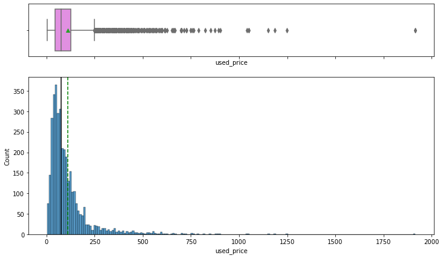

```python
histogram_boxplot(bc, 'used_price')
```

#### Observations on New Price

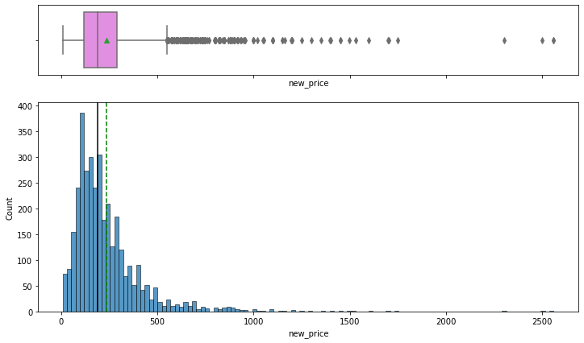

```python
histogram_boxplot(bc, 'new_price')
```

#### Observations on Year of Release

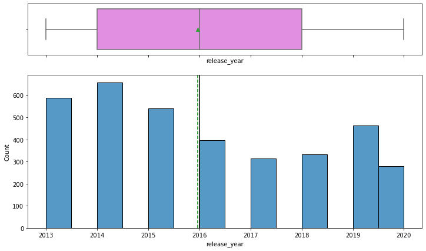

```python
histogram_boxplot(bc, 'release_year')
```

#### Observations

1. Both the mean and median are very close at around 2016
2. However, most of the phones were realeased during 2014 with 2013 coming a close second

#### Observations on Number of Days Used

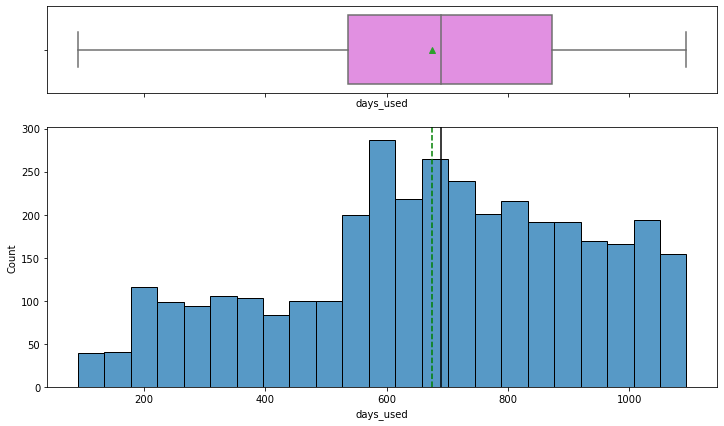

```python
histogram_boxplot(bc, 'days_used')
```

#### Observations on Battery

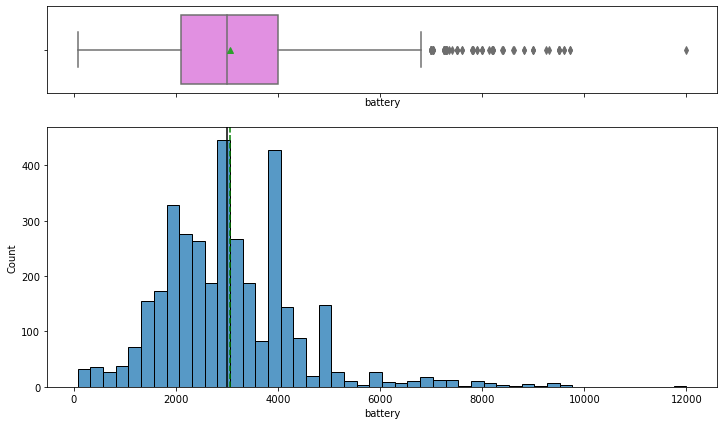

```python
histogram_boxplot(bc, 'battery')
```

#### Observations

```python
# function to create labeled barplots


def labeled_barplot(data, feature, perc=False, n=None):
    """
    Barplot with percentage at the top

    data: dataframe
    feature: dataframe column
    perc: whether to display percentages instead of count (default is False)
    n: displays the top n category levels (default is None, i.e., display all levels)
    """

    total = len(data[feature])  # length of the column
    count = data[feature].nunique()
    if n is None:
        plt.figure(figsize=(count + 1, 5))
    else:
        plt.figure(figsize=(n + 1, 5))

    plt.xticks(rotation=90, fontsize=15)
    ax = sns.countplot(
        data=data,
        x=feature,
        palette="Paired",
        order=data[feature].value_counts().index[:n].sort_values(),
    )

    for p in ax.patches:
        if perc == True:
            label = "{:.1f}%".format(
                100 * p.get_height() / total
            )  # percentage of each class of the category
        else:
            label = p.get_height()  # count of each level of the category

        x = p.get_x() + p.get_width() / 2  # width of the plot
        y = p.get_height()  # height of the plot

        ax.annotate(
            label,
            (x, y),
            ha="center",
            va="center",
            size=12,
            xytext=(0, 5),
            textcoords="offset points",
        )  # annotate the percentage

    plt.show()  # show the plot
```

#### Observations on Brand Name

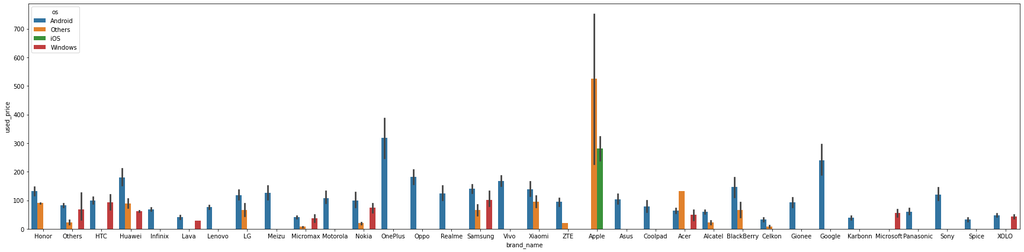

```python
plt.figure(figsize=(30,7))
sns.barplot(x='brand_name',y='used_price',hue='os',data=bc)
plt.show()
```

#### Observations on OS

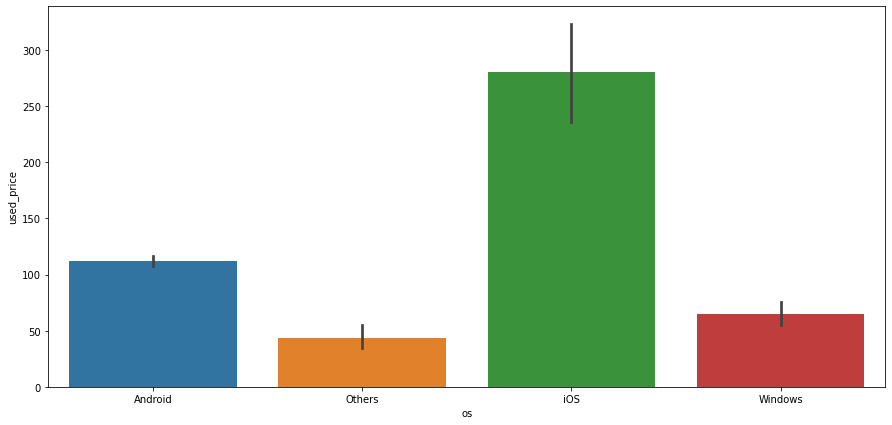

```python
plt.figure(figsize=(15,7))
sns.barplot(x='os',y='used_price',data=bc)
plt.show()
```

#### Observations

1. iOS has the highest *used_price*
2. Android has the second highest, then Windows

## Bivariate Analysis

### Correlations

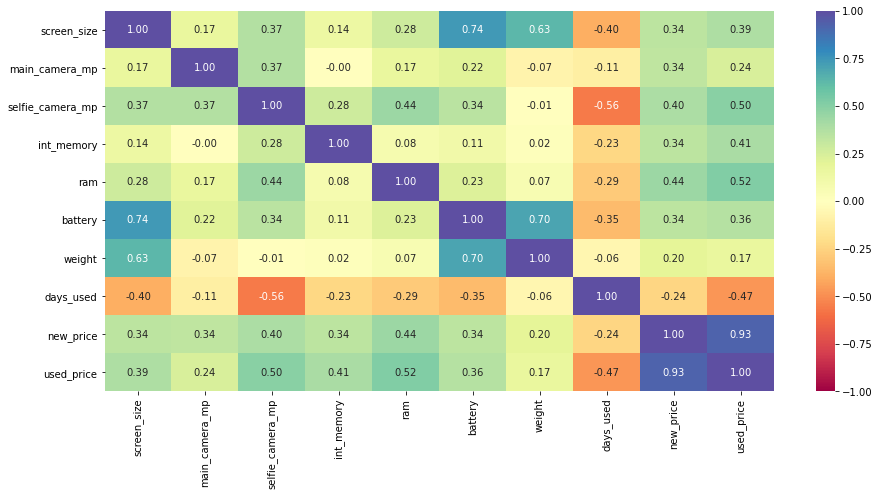

```python
numeric_columns = bc.select_dtypes(include=np.number).columns.tolist()
numeric_columns.remove("release_year")  # dropping release_year column as it is temporal variable

# correlation heatmap
plt.figure(figsize=(15, 7))
sns.heatmap(
    bc[numeric_columns].corr(),
    annot=True,
    vmin=-1,
    vmax=1,
    fmt=".2f",
    cmap="Spectral",
)
plt.show()
```

#### Observations

1. New_price and used_price are very highly positively correlated as is to be expected which means that the higher the new price the higher the used price
2. The used_price is negatively correlated with the number of days used
3. Battery, weight and screen size are all relatively highly correlated indicating that the physical features are all relatively highly correlated.

### Variables: Highly Correlated with Used Price

#### Price Through the Years

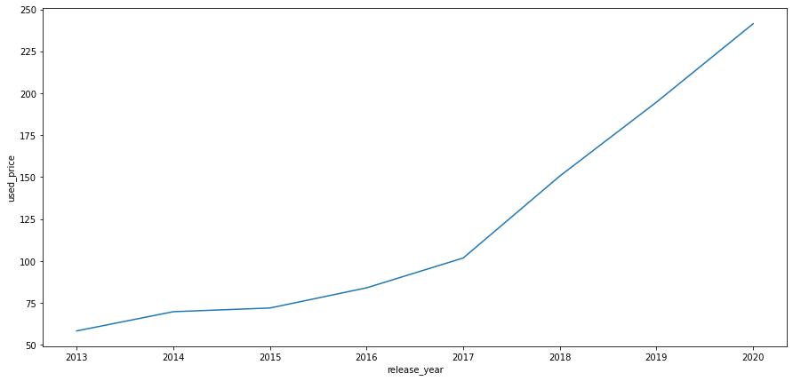

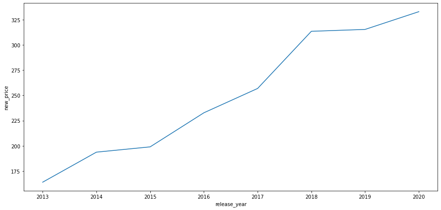

```python
plt.figure(figsize=(15, 7))
sns.lineplot(x="release_year", y="used_price", data=bc, ci=None)
plt.show()

plt.figure(figsize=(15, 7))
sns.lineplot(x="release_year", y="new_price", data=bc, ci=None)
plt.show()
```

#### DIstribution of Used Phones

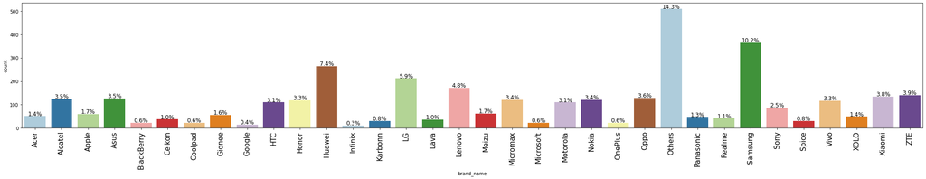

```python
labeled_barplot(bc, "brand_name", perc=True)
```

#### Observations

1. Others, Samsung and Huawei make up 31.9%

#### Percentage of Phones By OS

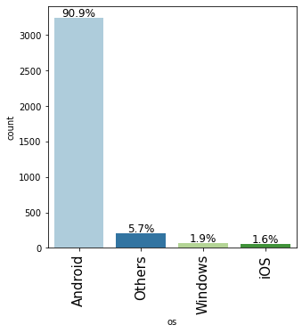

```python
labeled_barplot(bc, "os", perc=True)
```

#### Observations

1. Android phones dominate with over 90% of the market
2. Windows and iOS both have less than 2%

#### Ram vs Brand

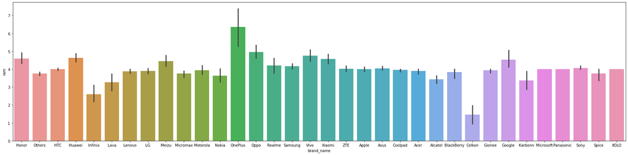

```python
plt.figure(figsize=(30, 7))
sns.barplot(y="ram", x="brand_name", data=bc)
plt.show()
```

#### Observations

1. Most phones have a ram size of ~4GB
2. However, some of them are much lower than the others with Oneplus being much higher than the average

#### Phone Brand vs Large Battery Size

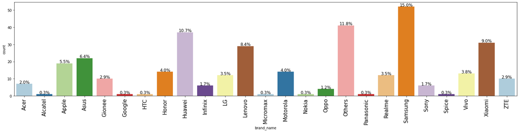

```python
#creation of a dataframe with battery levels higher than 4500 mAh
batt_high=pd.DataFrame(bc[bc.battery > 4500])

labeled_barplot(batt_high, "brand_name", perc=True)
```

```python
batt_high.shape
```

```
(346, 15)
```

#### Observations

1. The number of phones under consideration is 346
2. For phones with a battery higher than 4500 mAh, Samsung, Lenovo, Huawei, Asus, Apple and Others make up ~58%

#### Phone Brand vs Large Screen Size

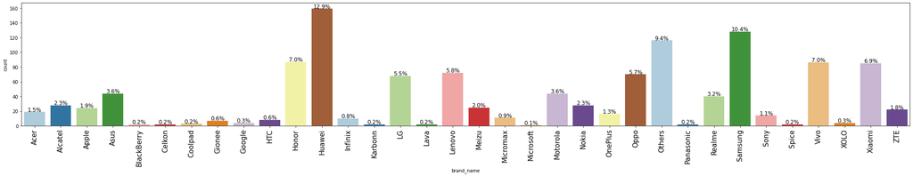

```python
#creation of a dataframe with screen size higher than 6 inches
screen_large=pd.DataFrame(bc[bc.screen_size > (6*2.54)])###2.54 is the rate of conversion from inches to cm

labeled_barplot(screen_large, "brand_name", perc=True)
```

```python
screen_large.shape
```

```
(1235, 15)
```

#### Observations

1. The number of phones under consideration is 1235
2. Huawei, Samsung, Others, Lenovo, Vivo, Honor make up ~53% of the phones

#### Phone Brand vs High Quality Selfie Cameras

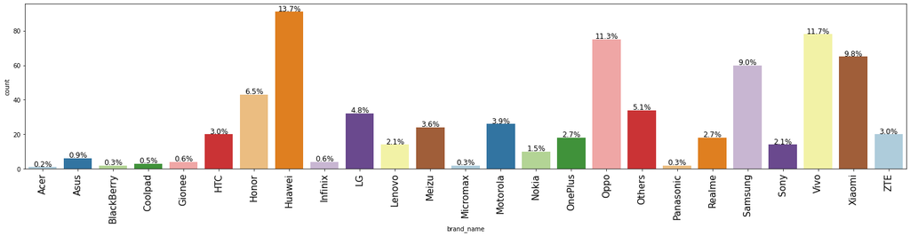

```python
#creation of a dataframe with selfie camera resolution higher than 8mp
cam_quality=pd.DataFrame(bc[bc.selfie_camera_mp > 8])

labeled_barplot(cam_quality, "brand_name", perc=True)
```

```python
cam_quality.shape
```

```
(666, 15)
```

#### Observations

1. The number of phones under consideration is 666
2. Huawei, Oppo, Samsung, Vivo, Xiaomi make ~55% of the phones

#### Conversion of Object Type to Category Type

```python
bc["brand_name"] = bc["brand_name"].astype("category")
bc["os"] = bc["os"].astype("category")
bc["4g"] = bc["4g"].astype("category")
bc["5g"] = bc["5g"].astype("category")
```

# Outlier Detection

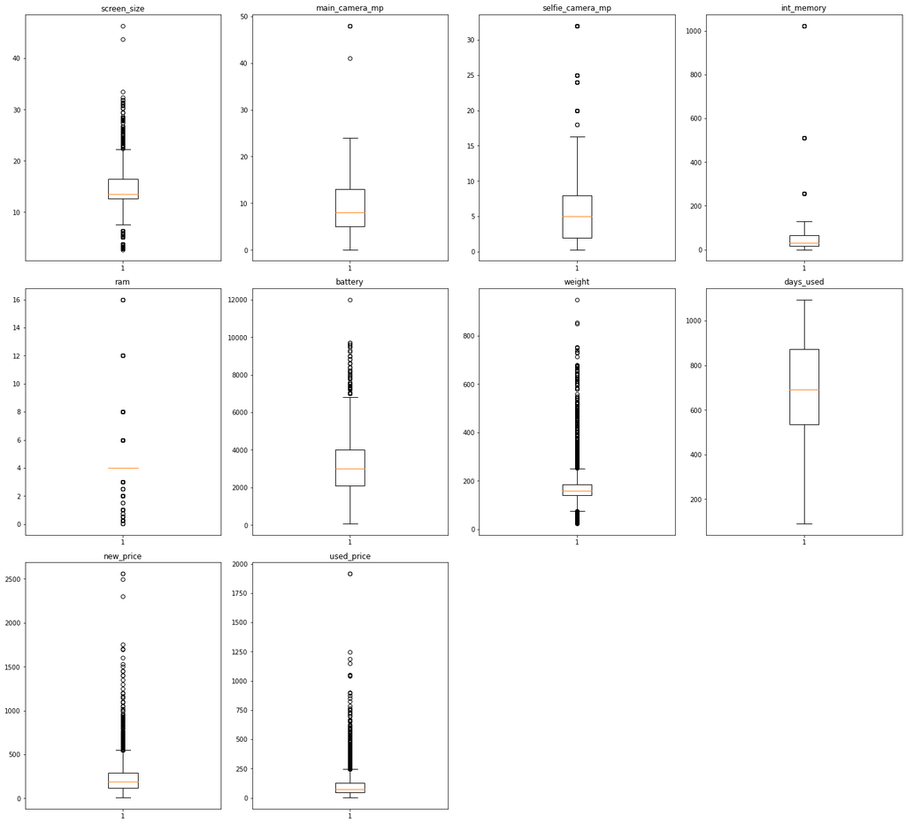

```python
# let's plot the boxplots of all columns to check for outliers
plt.figure(figsize=(20, 30))

for i, variable in enumerate(numeric_columns):
    plt.subplot(5, 4, i + 1)
    plt.boxplot(bc[variable], whis=1.5)
    plt.tight_layout()
    plt.title(variable)

plt.show()
```

#### Observations

1. Most numerical columns have upper outliers
2. Days_used has no outliers
3. weight, ram and scree_size have lower outliers
4. We will treat these outliers as these might adversely affect the predictive power of linear model. However, in real life, these outliers may be due to non-linear pattern in the data or can be important information.
5. Sometimes outliers in the independent variable can adversely impact the linear model. This can be checked by building the model with and without outliers and comparing the model performances.

#### Outlier Treatment

```python
def treat_outliers(bc, col):
    """
    treats outliers in a variable
    col: str, name of the numerical variable
    bc: dataframe
    col: name of the column
    """
    Q1 = bc[col].quantile(0.25)  # 25th quantile
    Q3 = bc[col].quantile(0.75)  # 75th quantile
    IQR = Q3 - Q1
    Lower_Whisker = Q1 - 1.5 * IQR
    Upper_Whisker = Q3 + 1.5 * IQR

    # all the values smaller than Lower_Whisker will be assigned the value of Lower_Whisker
    # all the values greater than Upper_Whisker will be assigned the value of Upper_Whisker
    bc[col] = np.clip(bc[col], Lower_Whisker, Upper_Whisker)

    return bc


def treat_outliers_all(bc, col_list):
    """
    treat outlier in all numerical variables
    col_list: list of numerical variables
    bc: data frame
    """
    for c in col_list:
        bc = treat_outliers(bc, c)

    return bc
```

```python
# treating the outliers
numerical_col = bc.select_dtypes(include=np.number).columns.tolist()
bc = treat_outliers_all(bc, numerical_col)
```

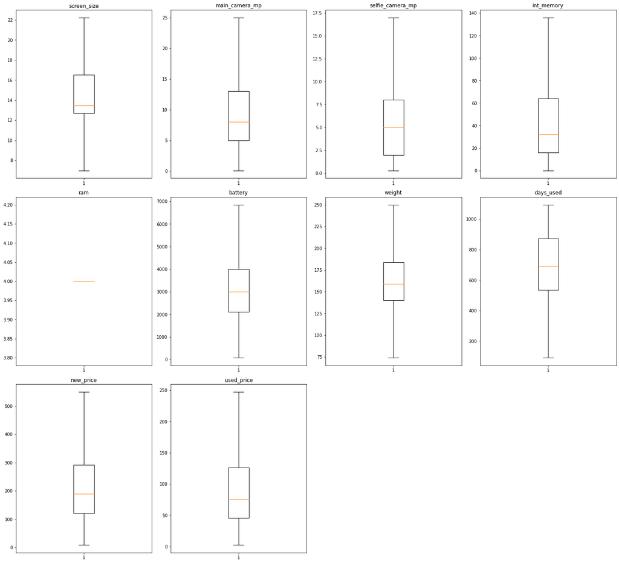

```python
# let's plot the boxplots of all columns to check for outlier treatment
plt.figure(figsize=(20, 30))

for i, variable in enumerate(numeric_columns):
    plt.subplot(5, 4, i + 1)
    plt.boxplot(bc[variable], whis=1.5)
    plt.tight_layout()
    plt.title(variable)

plt.show()
```

Upon observation, there are no more outliers

# Linear Model Building

1. We want to predict the used price.
2. Before we proceed to build a model, we'll have to encode categorical features.
3. We'll split the data into train and test to be able to evaluate the model that we build on the train data.
4. We will build a Linear Regression model using the train data and then check it's performance.

```python
# defining X and y variables
X = bc.drop(["used_price"], axis=1)
y = bc["used_price"]

print(X.head())
print(y.head())
```

```
  brand_name       os  screen_size   4g   5g  main_camera_mp  \
0      Honor  Android       22.225  yes   no            13.0
1      Honor  Android       22.225  yes  yes            13.0
2      Honor  Android       22.225  yes  yes            13.0
3      Honor  Android       22.225  yes  yes            13.0
4      Honor  Android       15.720  yes   no            13.0

   selfie_camera_mp  int_memory  ram  battery  weight  release_year  \
0               5.0        64.0  4.0   3020.0   146.0          2020
1              16.0       128.0  4.0   4300.0   213.0          2020
2               8.0       128.0  4.0   4200.0   213.0          2020
3               8.0        64.0  4.0   6850.0   250.0          2020
4               8.0        64.0  4.0   5000.0   185.0          2020

   days_used  new_price
0        127     111.62
1        325     249.39
2        162     359.47
3        345     278.93
4        293     140.87
0     86.9600
1    161.4900
2    247.1925
3    180.2300
4    103.8000
Name: used_price, dtype: float64
```

```python
X = pd.get_dummies(
    X,
    columns=X.select_dtypes(include=["object", "category"]).columns.tolist(),
    drop_first=True,
)
X.head()
```

|  | screen_size | main_camera_mp | selfie_camera_mp | int_memory | ram | battery | weight | release_year | days_used | new_price | brand_name_Alcatel | brand_name_Apple | brand_name_Asus | brand_name_BlackBerry | brand_name_Celkon | brand_name_Coolpad | brand_name_Gionee | brand_name_Google | brand_name_HTC | brand_name_Honor | brand_name_Huawei | brand_name_Infinix | brand_name_Karbonn | brand_name_LG | brand_name_Lava | brand_name_Lenovo | brand_name_Meizu | brand_name_Micromax | brand_name_Microsoft | … |
| --- | --- | --- | --- | --- | --- | --- | --- | --- | --- | --- | --- | --- | --- | --- | --- | --- | --- | --- | --- | --- | --- | --- | --- | --- | --- | --- | --- | --- | --- | --- |
| 0 | 22.225 | 13.0 | 5.0 | 64.0 | 4.0 | 3020.0 | 146.0 | 2020 | 127 | 111.62 | 0 | 0 | 0 | 0 | 0 | 0 | 0 | 0 | 0 | 1 | 0 | 0 | 0 | 0 | 0 | 0 | 0 | 0 | 0 | … |
| 1 | 22.225 | 13.0 | 16.0 | 128.0 | 4.0 | 4300.0 | 213.0 | 2020 | 325 | 249.39 | 0 | 0 | 0 | 0 | 0 | 0 | 0 | 0 | 0 | 1 | 0 | 0 | 0 | 0 | 0 | 0 | 0 | 0 | 0 | … |
| 2 | 22.225 | 13.0 | 8.0 | 128.0 | 4.0 | 4200.0 | 213.0 | 2020 | 162 | 359.47 | 0 | 0 | 0 | 0 | 0 | 0 | 0 | 0 | 0 | 1 | 0 | 0 | 0 | 0 | 0 | 0 | 0 | 0 | 0 | … |
| 3 | 22.225 | 13.0 | 8.0 | 64.0 | 4.0 | 6850.0 | 250.0 | 2020 | 345 | 278.93 | 0 | 0 | 0 | 0 | 0 | 0 | 0 | 0 | 0 | 1 | 0 | 0 | 0 | 0 | 0 | 0 | 0 | 0 | 0 | … |
| 4 | 15.720 | 13.0 | 8.0 | 64.0 | 4.0 | 5000.0 | 185.0 | 2020 | 293 | 140.87 | 0 | 0 | 0 | 0 | 0 | 0 | 0 | 0 | 0 | 1 | 0 | 0 | 0 | 0 | 0 | 0 | 0 | 0 | 0 | … |

```python
# splitting the data in 70:30 ratio for train to test data

x_train, x_test, y_train, y_test = train_test_split(
    X, y, test_size=0.3, random_state=1
)
```

```python
print("Number of rows in train data =", x_train.shape[0])
print("Number of rows in test data =", x_test.shape[0])
```

```
Number of rows in train data = 2499
Number of rows in test data = 1072
```

```python
# fitting the model on the train data (70% of the whole data)
from sklearn.linear_model import LinearRegression

linearregression = LinearRegression()
linearregression.fit(x_train, y_train)
```

```
LinearRegression()
```

```python
print('The intercept is ',linearregression.intercept_)
print('The slopes of the various variables are ',linearregression.coef_)
```

```
The intercept is  650.6843510069632
The slopes of the various variables are  [ 4.03778757e-01 -4.38579325e-01  8.37275213e-01  1.06295165e-01
  4.81910623e-11 -1.11335948e-04 -1.58722550e-02 -2.92804911e-01
 -8.44522408e-02  3.79859007e-01  1.84475996e+00 -1.37681762e+01
  2.49083432e+00  1.07808106e+01 -3.54637133e+00  2.40512281e+00
 -3.80407947e+00  1.63763700e+01  7.51625629e-01 -4.02134693e-01
  3.23954287e-01 -1.59799236e+01 -6.27702482e-01  2.88197398e+00
  8.71318052e-01 -2.03483472e+00 -3.51848068e-01  3.43107397e+00
  1.85781114e+00 -1.76265004e+00 -7.41626413e+00 -1.53973232e+01
 -1.75094413e+00  9.51038846e-01 -1.41560992e+00 -2.06597048e+00
  1.39668540e+00  4.14670701e+00  4.96195237e+00  1.02322261e+00
  3.27185521e+00 -1.39161177e+00  9.37581206e-01 -4.10349266e+00
  9.18334575e-01  2.47206371e+01 -1.68620870e+00  2.46893263e+00]
```

```python
coef_bc = pd.DataFrame(
    np.append(linearregression.coef_, linearregression.intercept_),
    index=x_train.columns.tolist() + ["Intercept"],
    columns=["Coefficients"],
)

coef_bc
```

|  | Coefficients |
| --- | --- |
| screen_size | 4.037788e-01 |
| main_camera_mp | -4.385793e-01 |
| selfie_camera_mp | 8.372752e-01 |
| int_memory | 1.062952e-01 |
| ram | 4.819106e-11 |
| battery | -1.113359e-04 |
| weight | -1.587225e-02 |
| release_year | -2.928049e-01 |
| days_used | -8.445224e-02 |
| new_price | 3.798590e-01 |
| brand_name_Alcatel | 1.844760e+00 |
| brand_name_Apple | -1.376818e+01 |
| brand_name_Asus | 2.490834e+00 |
| brand_name_BlackBerry | 1.078081e+01 |
| brand_name_Celkon | -3.546371e+00 |
| brand_name_Coolpad | 2.405123e+00 |
| brand_name_Gionee | -3.804079e+00 |
| brand_name_Google | 1.637637e+01 |
| brand_name_HTC | 7.516256e-01 |
| brand_name_Honor | -4.021347e-01 |
| brand_name_Huawei | 3.239543e-01 |
| brand_name_Infinix | -1.597992e+01 |
| brand_name_Karbonn | -6.277025e-01 |
| brand_name_LG | 2.881974e+00 |
| brand_name_Lava | 8.713181e-01 |
| brand_name_Lenovo | -2.034835e+00 |
| brand_name_Meizu | -3.518481e-01 |
| brand_name_Micromax | 3.431074e+00 |
| brand_name_Microsoft | 1.857811e+00 |
| brand_name_Motorola | -1.762650e+00 |
| brand_name_Nokia | -7.416264e+00 |
| brand_name_OnePlus | -1.539732e+01 |
| brand_name_Oppo | -1.750944e+00 |
| brand_name_Others | 9.510388e-01 |
| brand_name_Panasonic | -1.415610e+00 |
| brand_name_Realme | -2.065970e+00 |
| brand_name_Samsung | 1.396685e+00 |
| brand_name_Sony | 4.146707e+00 |
| brand_name_Spice | 4.961952e+00 |
| brand_name_Vivo | 1.023223e+00 |
| brand_name_XOLO | 3.271855e+00 |
| brand_name_Xiaomi | -1.391612e+00 |
| brand_name_ZTE | 9.375812e-01 |
| os_Others | -4.103493e+00 |
| os_Windows | 9.183346e-01 |
| os_iOS | 2.472064e+01 |
| 4g_yes | -1.686209e+00 |
| 5g_yes | 2.468933e+00 |
| Intercept | 6.506844e+02 |

**Let's check the performance of the model using different metrics.**

- We will be using metric functions defined in sklearn for RMSE, MAE, and $R^2$.
- We will define a function to calculate MAPE and adjusted $R^2$.
  - The mean absolute percentage error (MAPE) measures the accuracy of predictions as a percentage, and can be calculated as the average absolute percent error for each predicted value minus actual values divided by actual values. It works best if there are no extreme values in the data and none of the actual values are 0.
- We will create a function which will print out all the above metrics in one go.

```python
# function to compute adjusted R-squared
def adj_r2_score(predictors, targets, predictions):
    r2 = r2_score(targets, predictions)
    n = predictors.shape[0]
    k = predictors.shape[1]
    return 1 - ((1 - r2) * (n - 1) / (n - k - 1))


# function to compute MAPE
def mape_score(targets, predictions):
    return np.mean(np.abs(targets - predictions) / targets) * 100


# function to compute different metrics to check performance of a regression model
def model_performance_regression(model, predictors, target):
    """
    Function to compute different metrics to check regression model performance

    model: regressor
    predictors: independent variables
    target: dependent variable
    """

    # predicting using the independent variables
    pred = model.predict(predictors)

    r2 = r2_score(target, pred)  # to compute R-squared
    adjr2 = adj_r2_score(predictors, target, pred)  # to compute adjusted R-squared
    rmse = np.sqrt(mean_squared_error(target, pred))  # to compute RMSE
    mae = mean_absolute_error(target, pred)  # to compute MAE
    mape = mape_score(target, pred)  # to compute MAPE

    # creating a dataframe of metrics
    bc_perf = pd.DataFrame(
        {
            "RMSE": rmse,
            "MAE": mae,
            "R-squared": r2,
            "Adj. R-squared": adjr2,
            "MAPE": mape,
        },
        index=[0],
    )

    return bc_perf
```

```python
# checking model performance on train set (seen 70% data)
print("Training Performance\n")
linearregression_train_perf = model_performance_regression(
    linearregression, x_train, y_train
)
linearregression_train_perf
```

```
Training Performance
```

|  | RMSE | MAE | R-squared | Adj. R-squared | MAPE |
| --- | --- | --- | --- | --- | --- |
| 0 | 13.685352 | 10.126696 | 0.957179 | 0.95634 | 17.780387 |

```python
# checking model performance on test set (seen 30% data)
print("Test Performance\n")
linearregression_test_perf = model_performance_regression(
    linearregression, x_test, y_test
)
linearregression_test_perf
```

```
Test Performance
```

|  | RMSE | MAE | R-squared | Adj. R-squared | MAPE |
| --- | --- | --- | --- | --- | --- |
| 0 | 14.541195 | 10.519978 | 0.951665 | 0.949397 | 18.455811 |

### Linear Regression using Statsmodels

```python
x_train1 = sm.add_constant(x_train)
# adding constant to the test data
x_test1 = sm.add_constant(x_test)

olsmod0 = sm.OLS(y_train, x_train1).fit()
print(olsmod0.summary())
```

```
                            OLS Regression Results
==============================================================================
Dep. Variable:             used_price   R-squared:                       0.957
Model:                            OLS   Adj. R-squared:                  0.956
Method:                 Least Squares   F-statistic:                     1166.
Date:                Fri, 01 Oct 2021   Prob (F-statistic):               0.00
Time:                        01:05:11   Log-Likelihood:                -10084.
No. Observations:                2499   AIC:                         2.026e+04
Df Residuals:                    2451   BIC:                         2.054e+04
Df Model:                          47
Covariance Type:            nonrobust
=========================================================================================
                            coef    std err          t      P>|t|      [0.025      0.975]
-----------------------------------------------------------------------------------------
screen_size               0.4038      0.127      3.186      0.001       0.155       0.652
main_camera_mp           -0.4386      0.091     -4.801      0.000      -0.618      -0.259
selfie_camera_mp          0.8373      0.102      8.227      0.000       0.638       1.037
int_memory                0.1063      0.011      9.862      0.000       0.085       0.127
ram                     162.6711    136.515      1.192      0.234    -105.025     430.367
battery                  -0.0001      0.000     -0.272      0.786      -0.001       0.001
weight                   -0.0159      0.012     -1.342      0.180      -0.039       0.007
release_year             -0.2928      0.271     -1.081      0.280      -0.824       0.238
days_used                -0.0845      0.002    -46.952      0.000      -0.088      -0.081
new_price                 0.3799      0.003    113.361      0.000       0.373       0.386
brand_name_Alcatel        1.8448      2.856      0.646      0.518      -3.757       7.446
brand_name_Apple        -13.7682     10.303     -1.336      0.182     -33.971       6.434
brand_name_Asus           2.4908      2.779      0.896      0.370      -2.958       7.940
brand_name_BlackBerry    10.7808      4.281      2.518      0.012       2.385      19.176
brand_name_Celkon        -3.5464      3.845     -0.922      0.356     -11.086       3.993
brand_name_Coolpad        2.4051      4.535      0.530      0.596      -6.488      11.298
brand_name_Gionee        -3.8041      3.221     -1.181      0.238     -10.120       2.512
brand_name_Google        16.3764      5.229      3.132      0.002       6.124      26.629
brand_name_HTC            0.7516      2.844      0.264      0.792      -4.825       6.328
brand_name_Honor         -0.4021      2.904     -0.138      0.890      -6.097       5.292
brand_name_Huawei         0.3240      2.601      0.125      0.901      -4.777       5.425
brand_name_Infinix      -15.9799      5.506     -2.902      0.004     -26.776      -5.184
brand_name_Karbonn       -0.6277      3.746     -0.168      0.867      -7.973       6.717
brand_name_LG             2.8820      2.639      1.092      0.275      -2.292       8.056
brand_name_Lava           0.8713      3.689      0.236      0.813      -6.363       8.106
brand_name_Lenovo        -2.0348      2.678     -0.760      0.447      -7.287       3.217
```

[output cut: 18 more lines]

```
os_Windows                0.9183      2.653      0.346      0.729      -4.284       6.121
os_iOS                   24.7206     10.221      2.419      0.016       4.679      44.763
4g_yes                   -1.6862      0.909     -1.856      0.064      -3.468       0.096
5g_yes                    2.4689      1.680      1.470      0.142      -0.825       5.763
==============================================================================
Omnibus:                      233.732   Durbin-Watson:                   1.988
Prob(Omnibus):                  0.000   Jarque-Bera (JB):              519.521
Skew:                           0.575   Prob(JB):                    1.54e-113
Kurtosis:                       4.915   Cond. No.                     1.92e+06
==============================================================================

Notes:
[1] Standard Errors assume that the covariance matrix of the errors is correctly specified.
[2] The condition number is large, 1.92e+06. This might indicate that there are
strong multicollinearity or other numerical problems.
```

#### Observations

1. Negative values of the coefficient show that used_price decreases with the increase of corresponding attribute value.
2. Positive values of the coefficient show that used_price increases with the increase of corresponding attribute value.
3. p-value of a variable indicates if the variable is significant or not. If we consider the significance level to be 0.05 (5%), then any variable with a p-value less than 0.05 would be considered significant.
4. But these variables might contain multicollinearity, which will affect the p-values.
5. So, we need to deal with multicollinearity and check the other assumptions of linear regression first, and then look at the p-values.

### Linear Regression Assumptions

#### Test fot Multicollinearity

```python
from statsmodels.stats.outliers_influence import variance_inflation_factor

# we will define a function to check VIF
def checking_vif(predictors):
    vif = pd.DataFrame()
    vif["feature"] = predictors.columns

    # calculating VIF for each feature
    vif["VIF"] = [
        variance_inflation_factor(predictors.values, i)
        for i in range(len(predictors.columns))
    ]
    return vif
```

```python
checking_vif(x_train1)
```

|  | feature | VIF |
| --- | --- | --- |
| 0 | screen_size | 3.685902e+00 |
| 1 | main_camera_mp | 2.197054e+00 |
| 2 | selfie_camera_mp | 3.806049e+00 |
| 3 | int_memory | 2.293852e+00 |
| 4 | ram | 3.902212e+06 |
| 5 | battery | 3.628708e+00 |
| 6 | weight | 3.128690e+00 |
| 7 | release_year | 5.070815e+00 |
| 8 | days_used | 2.633924e+00 |
| 9 | new_price | 2.707144e+00 |
| 10 | brand_name_Alcatel | 3.108536e+00 |
| 11 | brand_name_Apple | 2.295308e+01 |
| 12 | brand_name_Asus | 3.470481e+00 |
| 13 | brand_name_BlackBerry | 1.525999e+00 |
| 14 | brand_name_Celkon | 1.840126e+00 |
| 15 | brand_name_Coolpad | 1.392910e+00 |
| 16 | brand_name_Gionee | 2.138189e+00 |
| 17 | brand_name_Google | 1.283808e+00 |
| 18 | brand_name_HTC | 3.279939e+00 |
| 19 | brand_name_Honor | 3.337186e+00 |
| 20 | brand_name_Huawei | 6.070545e+00 |
| 21 | brand_name_Infinix | 1.265892e+00 |
| 22 | brand_name_Karbonn | 1.674315e+00 |
| 23 | brand_name_LG | 5.109285e+00 |
| 24 | brand_name_Lava | 1.694347e+00 |
| 25 | brand_name_Lenovo | 4.257540e+00 |
| 26 | brand_name_Meizu | 2.263596e+00 |
| 27 | brand_name_Micromax | 3.229281e+00 |
| 28 | brand_name_Microsoft | 1.857296e+00 |
| 29 | brand_name_Motorola | 3.105089e+00 |
| 30 | brand_name_Nokia | 3.614530e+00 |
| 31 | brand_name_OnePlus | 1.641474e+00 |
| 32 | brand_name_Oppo | 3.890219e+00 |
| 33 | brand_name_Others | 9.571702e+00 |
| 34 | brand_name_Panasonic | 1.958774e+00 |
| 35 | brand_name_Realme | 1.915884e+00 |
| 36 | brand_name_Samsung | 7.891391e+00 |
| 37 | brand_name_Sony | 2.855222e+00 |
| 38 | brand_name_Spice | 1.752856e+00 |
| 39 | brand_name_Vivo | 3.483939e+00 |
| 40 | brand_name_XOLO | 2.016149e+00 |
| 41 | brand_name_Xiaomi | 4.019305e+00 |
| 42 | brand_name_ZTE | 3.661940e+00 |
| 43 | os_Others | 1.583045e+00 |
| 44 | os_Windows | 1.593489e+00 |
| 45 | os_iOS | 2.153139e+01 |
| 46 | 4g_yes | 2.412969e+00 |
| 47 | 5g_yes | 1.459272e+00 |

#### Observations

1. brand_name_Samsung,brand_name_Huawei,brand_name_LG and brand_name_Others have VIF slightly greater than 5.
2. brand_name_Apple and os_iOS have a VIF score of much greater than 5. The two variables are definitely correlated with each other
3. ram has a VIF of much greater than 5

#### Removing Multicollinearity

```python
def treating_multicollinearity(predictors, target, high_vif_columns):
    """
    Checking the effect of dropping the columns showing high multicollinearity
    on model performance (adj. R-squared and RMSE)

    predictors: independent variables
    target: dependent variable
    high_vif_columns: columns having high VIF
    """
    # empty lists to store adj. R-squared and RMSE values
    adj_r2 = []
    rmse = []

    # build ols models by dropping one of the high VIF columns at a time
    # store the adjusted R-squared and RMSE in the lists defined previously
    for cols in high_vif_columns:
        # defining the new train set
        train = predictors.loc[:, ~predictors.columns.str.startswith(cols)]

        # create the model
        olsmodel = sm.OLS(target, train).fit()

        # adding adj. R-squared and RMSE to the lists
        adj_r2.append(olsmodel.rsquared_adj)
        rmse.append(np.sqrt(olsmodel.mse_resid))

    # creating a dataframe for the results
    temp = pd.DataFrame(
        {
            "col": high_vif_columns,
            "Adj. R-squared after_dropping col": adj_r2,
            "RMSE after dropping col": rmse,
        }
    ).sort_values(by="Adj. R-squared after_dropping col", ascending=False)
    temp.reset_index(drop=True, inplace=True)

    return temp
```

#### Removing Multicollinearity

```python
col_list = [
    'ram',
'brand_name_Apple',
'os_iOS',
'brand_name_Others',
'brand_name_Samsung',
'brand_name_Huawei',
'brand_name_LG',
]
res = treating_multicollinearity(x_train1, y_train, col_list)
res
```

[output not shown]

1. Dropping *ram* will have the greatest effect on the predictive power of the model
2. Dropping *os_iOS* and brand_name_Others

```python
col_to_drop = 'os_iOS','brand_name_Others'
x_train2 = x_train1.loc[:, ~x_train1.columns.str.startswith(col_to_drop)]
x_test2 = x_test1.loc[:, ~x_test1.columns.str.startswith(col_to_drop)]

# Check VIF now
vif = checking_vif(x_train2)
print("VIF after dropping ", col_to_drop)
vif
```

```
VIF after dropping  ('os_iOS', 'brand_name_Others')
```

|  | feature | VIF |
| --- | --- | --- |
| 0 | screen_size | 3.678423e+00 |
| 1 | main_camera_mp | 2.190520e+00 |
| 2 | selfie_camera_mp | 3.796069e+00 |
| 3 | int_memory | 2.286853e+00 |
| 4 | ram | 3.898360e+06 |
| 5 | battery | 3.623269e+00 |
| 6 | weight | 3.125060e+00 |
| 7 | release_year | 5.064481e+00 |
| 8 | days_used | 2.632571e+00 |
| 9 | new_price | 2.706727e+00 |
| 10 | brand_name_Alcatel | 1.184818e+00 |
| 11 | brand_name_Apple | 1.295898e+00 |
| 12 | brand_name_Asus | 1.211921e+00 |
| 13 | brand_name_BlackBerry | 1.095086e+00 |
| 14 | brand_name_Celkon | 1.204496e+00 |
| 15 | brand_name_Coolpad | 1.046613e+00 |
| 16 | brand_name_Gionee | 1.102218e+00 |
| 17 | brand_name_Google | 1.041884e+00 |
| 18 | brand_name_HTC | 1.220327e+00 |
| 19 | brand_name_Honor | 1.330949e+00 |
| 20 | brand_name_Huawei | 1.513123e+00 |
| 21 | brand_name_Infinix | 1.052567e+00 |
| 22 | brand_name_Karbonn | 1.082851e+00 |
| 23 | brand_name_LG | 1.379481e+00 |
| 24 | brand_name_Lava | 1.073564e+00 |
| 25 | brand_name_Lenovo | 1.284202e+00 |
| 26 | brand_name_Meizu | 1.153250e+00 |
| 27 | brand_name_Micromax | 1.198775e+00 |
| 28 | brand_name_Microsoft | 1.518223e+00 |
| 29 | brand_name_Motorola | 1.226038e+00 |
| 30 | brand_name_Nokia | 1.401201e+00 |
| 31 | brand_name_OnePlus | 1.136172e+00 |
| 32 | brand_name_Oppo | 1.384079e+00 |
| 33 | brand_name_Panasonic | 1.092234e+00 |
| 34 | brand_name_Realme | 1.146328e+00 |
| 35 | brand_name_Samsung | 1.650966e+00 |
| 36 | brand_name_Sony | 1.220230e+00 |
| 37 | brand_name_Spice | 1.084678e+00 |
| 38 | brand_name_Vivo | 1.372234e+00 |
| 39 | brand_name_XOLO | 1.102391e+00 |
| 40 | brand_name_Xiaomi | 1.371177e+00 |
| 41 | brand_name_ZTE | 1.272022e+00 |
| 42 | os_Others | 1.541012e+00 |
| 43 | os_Windows | 1.590859e+00 |
| 44 | 4g_yes | 2.410790e+00 |
| 45 | 5g_yes | 1.458453e+00 |

Rechecking the model performance

```python
olsmod1 = sm.OLS(y_train, x_train2).fit()
print(olsmod1.summary())
```

```
                            OLS Regression Results
==============================================================================
Dep. Variable:             used_price   R-squared:                       0.957
Model:                            OLS   Adj. R-squared:                  0.956
Method:                 Least Squares   F-statistic:                     1215.
Date:                Fri, 01 Oct 2021   Prob (F-statistic):               0.00
Time:                        01:05:13   Log-Likelihood:                -10087.
No. Observations:                2499   AIC:                         2.027e+04
Df Residuals:                    2453   BIC:                         2.053e+04
Df Model:                          45
Covariance Type:            nonrobust
=========================================================================================
                            coef    std err          t      P>|t|      [0.025      0.975]
-----------------------------------------------------------------------------------------
screen_size               0.3957      0.127      3.122      0.002       0.147       0.644
main_camera_mp           -0.4507      0.091     -4.938      0.000      -0.630      -0.272
selfie_camera_mp          0.8498      0.102      8.355      0.000       0.650       1.049
int_memory                0.1050      0.011      9.751      0.000       0.084       0.126
ram                     164.2158    136.559      1.203      0.229    -103.566     431.998
battery                  -0.0001      0.000     -0.359      0.720      -0.001       0.001
weight                   -0.0166      0.012     -1.407      0.160      -0.040       0.007
release_year             -0.2953      0.271     -1.090      0.276      -0.827       0.236
days_used                -0.0844      0.002    -46.873      0.000      -0.088      -0.081
new_price                 0.3800      0.003    113.305      0.000       0.373       0.387
brand_name_Alcatel        0.9616      1.765      0.545      0.586      -2.499       4.423
brand_name_Apple          8.9283      2.450      3.644      0.000       4.124      13.733
brand_name_Asus           1.6351      1.643      0.995      0.320      -1.587       4.858
brand_name_BlackBerry    10.1475      3.630      2.796      0.005       3.030      17.265
brand_name_Celkon        -4.1834      3.113     -1.344      0.179     -10.288       1.922
brand_name_Coolpad        1.4885      3.934      0.378      0.705      -6.227       9.204
brand_name_Gionee        -4.7180      2.314     -2.039      0.042      -9.256      -0.180
brand_name_Google        15.5407      4.714      3.297      0.001       6.297      24.785
brand_name_HTC           -0.1752      1.736     -0.101      0.920      -3.580       3.229
brand_name_Honor         -1.2005      1.835     -0.654      0.513      -4.800       2.399
brand_name_Huawei        -0.5041      1.300     -0.388      0.698      -3.053       2.045
brand_name_Infinix      -16.8068      5.025     -3.345      0.001     -26.660      -6.954
brand_name_Karbonn       -1.6079      3.015     -0.533      0.594      -7.520       4.304
brand_name_LG             1.9782      1.372      1.442      0.150      -0.713       4.669
brand_name_Lava          -0.0729      2.939     -0.025      0.980      -5.836       5.691
brand_name_Lenovo        -2.8845      1.472     -1.959      0.050      -5.771       0.002
```

[output cut: 16 more lines]

```
os_Others                -4.6995      1.509     -3.115      0.002      -7.658      -1.741
os_Windows                0.7538      2.653      0.284      0.776      -4.449       5.957
4g_yes                   -1.6756      0.909     -1.843      0.065      -3.458       0.107
5g_yes                    2.5533      1.681      1.519      0.129      -0.742       5.849
==============================================================================
Omnibus:                      237.397   Durbin-Watson:                   1.992
Prob(Omnibus):                  0.000   Jarque-Bera (JB):              525.820
Skew:                           0.584   Prob(JB):                    6.60e-115
Kurtosis:                       4.919   Cond. No.                     1.92e+06
==============================================================================

Notes:
[1] Standard Errors assume that the covariance matrix of the errors is correctly specified.
[2] The condition number is large, 1.92e+06. This might indicate that there are
strong multicollinearity or other numerical problems.
```

#### Observations

```python
# initial list of columns
cols = x_train2.columns.tolist()

# setting an initial max p-value
max_p_value = 1

while len(cols) > 0:
    # defining the train set
    x_train_aux = x_train2[cols]

    # fitting the model
    model = sm.OLS(y_train, x_train_aux).fit()

    # getting the p-values and the maximum p-value
    p_values = model.pvalues
    max_p_value = max(p_values)

    # name of the variable with maximum p-value
    feature_with_p_max = p_values.idxmax()

    if max_p_value > 0.05:
        cols.remove(feature_with_p_max)
    else:
        break

selected_features = cols
print(selected_features)
```

```
['screen_size', 'main_camera_mp', 'selfie_camera_mp', 'int_memory', 'ram', 'days_used', 'new_price', 'brand_name_Apple', 'brand_name_BlackBerry', 'brand_name_Gionee', 'brand_name_Google', 'brand_name_Infinix', 'brand_name_Lenovo', 'brand_name_Nokia', 'brand_name_OnePlus', 'os_Others', '4g_yes']
```

```python
x_train3 = x_train2[selected_features]
x_test3 = x_test2[selected_features]
```

```python
olsmod2 = sm.OLS(y_train, x_train3).fit()
print(olsmod2.summary())
```

```
                            OLS Regression Results
==============================================================================
Dep. Variable:             used_price   R-squared:                       0.957
Model:                            OLS   Adj. R-squared:                  0.956
Method:                 Least Squares   F-statistic:                     3411.
Date:                Fri, 01 Oct 2021   Prob (F-statistic):               0.00
Time:                        01:05:14   Log-Likelihood:                -10104.
No. Observations:                2499   AIC:                         2.024e+04
Df Residuals:                    2482   BIC:                         2.034e+04
Df Model:                          16
Covariance Type:            nonrobust
=========================================================================================
                            coef    std err          t      P>|t|      [0.025      0.975]
-----------------------------------------------------------------------------------------
screen_size               0.2077      0.086      2.423      0.015       0.040       0.376
main_camera_mp           -0.4705      0.084     -5.607      0.000      -0.635      -0.306
selfie_camera_mp          0.7880      0.087      9.035      0.000       0.617       0.959
int_memory                0.0981      0.010      9.829      0.000       0.078       0.118
ram                      15.3469      0.491     31.271      0.000      14.385      16.309
days_used                -0.0834      0.001    -55.735      0.000      -0.086      -0.080
new_price                 0.3831      0.003    134.764      0.000       0.378       0.389
brand_name_Apple          7.9717      2.276      3.503      0.000       3.509      12.434
brand_name_BlackBerry    10.0841      3.546      2.844      0.004       3.130      17.038
brand_name_Gionee        -5.1342      2.219     -2.314      0.021      -9.485      -0.783
brand_name_Google        14.8476      4.642      3.199      0.001       5.746      23.950
brand_name_Infinix      -16.9793      4.948     -3.431      0.001     -26.683      -7.276
brand_name_Lenovo        -3.2361      1.314     -2.463      0.014      -5.813      -0.659
brand_name_Nokia         -7.8967      1.619     -4.879      0.000     -11.070      -4.723
brand_name_OnePlus      -15.1654      3.270     -4.638      0.000     -21.577      -8.754
os_Others                -5.0142      1.451     -3.455      0.001      -7.860      -2.168
4g_yes                   -2.3926      0.795     -3.011      0.003      -3.951      -0.834
==============================================================================
Omnibus:                      244.409   Durbin-Watson:                   1.977
Prob(Omnibus):                  0.000   Jarque-Bera (JB):              547.251
Skew:                           0.596   Prob(JB):                    1.47e-119
Kurtosis:                       4.958   Cond. No.                     1.34e+04
==============================================================================

Notes:
[1] Standard Errors assume that the covariance matrix of the errors is correctly specified.
[2] The condition number is large, 1.34e+04. This might indicate that there are
strong multicollinearity or other numerical problems.
```

#### Test For Linearity And Independence

```python
# let us create a dataframe with actual, fitted and residual values
df_pred = pd.DataFrame()

df_pred["Actual Values"] = y_train  # actual values
df_pred["Fitted Values"] = olsmod2.fittedvalues  # predicted values
df_pred["Residuals"] = olsmod2.resid  # residuals

df_pred.head()
```

|  | Actual Values | Fitted Values | Residuals |
| --- | --- | --- | --- |
| 1248 | 98.87 | 108.482198 | -9.612198 |
| 2206 | 132.62 | 145.060136 | -12.440136 |
| 1623 | 25.27 | 36.243076 | -10.973076 |
| 2245 | 104.26 | 109.328149 | -5.068149 |
| 1043 | 39.22 | 51.820086 | -12.600086 |

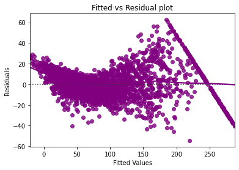

```python
# let's plot the fitted values vs residuals

sns.residplot(
    data=df_pred, x="Fitted Values", y="Residuals", color="purple", lowess=True
)
plt.xlabel("Fitted Values")
plt.ylabel("Residuals")
plt.title("Fitted vs Residual plot")
plt.show()
```

#### Test For Normality

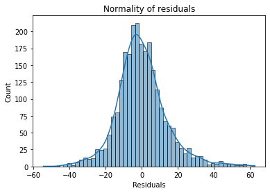

```python
sns.histplot(data=df_pred, x="Residuals", kde=True)
plt.title("Normality of residuals")
plt.show()
```

The histogram of residuals does have a bell shape.

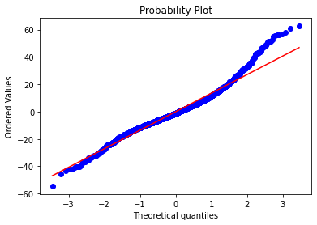

```python
stats.probplot(df_pred["Residuals"], dist="norm", plot=pylab)
plt.show()
```

The residuals more or less follow a straight line except for the upper right part of the tail.

```python
stats.shapiro(df_pred["Residuals"])
```

```
ShapiroResult(statistic=0.9678675532341003, pvalue=3.306325890782049e-23)
```

1. Since p-value < 0.05, the residuals are not normal as per the Shapiro-Wilk test.
2. Strictly speaking, the residuals are not normal.
3. However, as an approximation, we can accept this distribution as close to being normal.
4. So, the assumption is satisfied.

#### Test For Homoscedasticity

```python
name = ["F statistic", "p-value"]
test = sms.het_goldfeldquandt(df_pred["Residuals"], x_train3)
lzip(name, test)
```

```
[('F statistic', 0.9596933143530775), ('p-value', 0.7648513380992107)]
```

Since p-value > 0.05, we can say that the residuals are homoscedastic. So, this assumption is satisfied.

### Predictions on the Test Set

```python
pred = olsmod2.predict(x_test3)

df_pred_test = pd.DataFrame({"Actual": y_test, "Predicted": pred})
df_pred_test.sample(10, random_state=1)
```

|  | Actual | Predicted |
| --- | --- | --- |
| 255 | 194.45 | 171.689670 |
| 1398 | 170.24 | 149.913124 |
| 2253 | 164.76 | 207.530913 |
| 579 | 39.09 | 43.506403 |
| 3123 | 45.08 | 38.133298 |
| 1959 | 51.05 | 57.567546 |
| 3111 | 40.07 | 34.629583 |
| 1456 | 54.75 | 52.042979 |
| 3332 | 95.06 | 104.457796 |
| 855 | 44.03 | 47.821767 |

We can observe here that our model has returned pretty good prediction results, and the actual and predicted values are comparable.

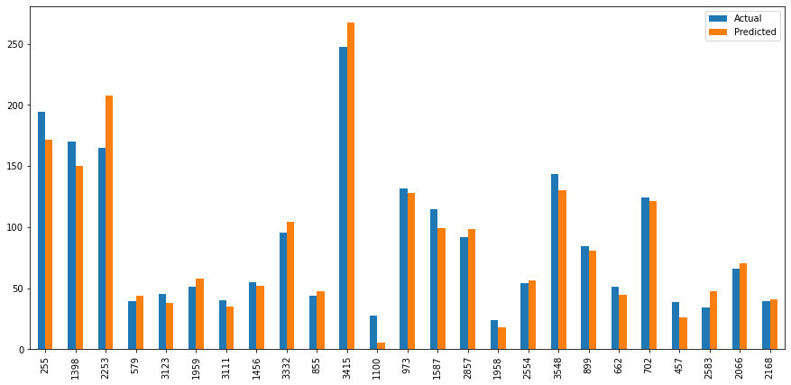

```python
# Visualisation of comparison results as a bar graph.
#**Note**: As the number of records is large, for representation purpose, we are taking a sample of 25 records only.

bc1 = df_pred_test.sample(25, random_state=1)
bc1.plot(kind="bar", figsize=(15, 7))
plt.show()
```

```python
# checking model performance on train set (seen 70% data)
print("Training Performance\n")
olsmod2_train_perf = model_performance_regression(olsmod2, x_train3, y_train)
olsmod2_train_perf
```

```
Training Performance
```

|  | RMSE | MAE | R-squared | Adj. R-squared | MAPE |
| --- | --- | --- | --- | --- | --- |
| 0 | 13.792708 | 10.186085 | 0.956504 | 0.956206 | 17.925214 |

```python
# checking model performance on test set (seen 30% data)
print("Test Performance\n")
olsmod2_test_perf = model_performance_regression(olsmod2, x_test3, y_test)
olsmod2_test_perf
```

```
Test Performance
```

|  | RMSE | MAE | R-squared | Adj. R-squared | MAPE |
| --- | --- | --- | --- | --- | --- |
| 0 | 14.269212 | 10.337965 | 0.953457 | 0.952706 | 17.945185 |

#### Observations

1. The model is able to explain ~95% of the variation in the data, which is very good.
2. The train and test RMSE and MAE are low and comparable. So, our model is not suffering from overfitting.
3. The MAPE on the test set suggests we can predict within 17.9% of the used price.
4. Hence, we can conclude the model *olsmod2* is good for prediction as well as inference purposes

#### Comparison of both models: sklearn and statsmodels

```python
# training performance comparison

models_train_comp_df = pd.concat(
    [linearregression_train_perf.T, olsmod2_train_perf.T],
    axis=1,
)

models_train_comp_df.columns = [
    "Linear Regression sklearn",
    "Linear Regression statsmodels",
]

print("Training performance comparison:")
models_train_comp_df
```

```
Training performance comparison:
```

|  | Linear Regression sklearn | Linear Regression statsmodels |
| --- | --- | --- |
| RMSE | 13.685352 | 13.792708 |
| MAE | 10.126696 | 10.186085 |
| R-squared | 0.957179 | 0.956504 |
| Adj. R-squared | 0.956340 | 0.956206 |
| MAPE | 17.780387 | 17.925214 |

```python
# test performance comparison

models_test_comp_df = pd.concat(
    [linearregression_test_perf.T, olsmod2_test_perf.T],
    axis=1,
)

models_test_comp_df.columns = [
    "Linear Regression sklearn",
    "Linear Regression statsmodels",
]

print("Test performance comparison:")
models_test_comp_df
```

```
Test performance comparison:
```

|  | Linear Regression sklearn | Linear Regression statsmodels |
| --- | --- | --- |
| RMSE | 14.541195 | 14.269212 |
| MAE | 10.519978 | 10.337965 |
| R-squared | 0.951665 | 0.953457 |
| Adj. R-squared | 0.949397 | 0.952706 |
| MAPE | 18.455811 | 17.945185 |

### The perormance of the two models are close to each other

```python
olsmodel_final = sm.OLS(y_train, x_train3).fit()
print(olsmodel_final.summary())
```

```
                            OLS Regression Results
==============================================================================
Dep. Variable:             used_price   R-squared:                       0.957
Model:                            OLS   Adj. R-squared:                  0.956
Method:                 Least Squares   F-statistic:                     3411.
Date:                Fri, 01 Oct 2021   Prob (F-statistic):               0.00
Time:                        01:05:20   Log-Likelihood:                -10104.
No. Observations:                2499   AIC:                         2.024e+04
Df Residuals:                    2482   BIC:                         2.034e+04
Df Model:                          16
Covariance Type:            nonrobust
=========================================================================================
                            coef    std err          t      P>|t|      [0.025      0.975]
-----------------------------------------------------------------------------------------
screen_size               0.2077      0.086      2.423      0.015       0.040       0.376
main_camera_mp           -0.4705      0.084     -5.607      0.000      -0.635      -0.306
selfie_camera_mp          0.7880      0.087      9.035      0.000       0.617       0.959
int_memory                0.0981      0.010      9.829      0.000       0.078       0.118
ram                      15.3469      0.491     31.271      0.000      14.385      16.309
days_used                -0.0834      0.001    -55.735      0.000      -0.086      -0.080
new_price                 0.3831      0.003    134.764      0.000       0.378       0.389
brand_name_Apple          7.9717      2.276      3.503      0.000       3.509      12.434
brand_name_BlackBerry    10.0841      3.546      2.844      0.004       3.130      17.038
brand_name_Gionee        -5.1342      2.219     -2.314      0.021      -9.485      -0.783
brand_name_Google        14.8476      4.642      3.199      0.001       5.746      23.950
brand_name_Infinix      -16.9793      4.948     -3.431      0.001     -26.683      -7.276
brand_name_Lenovo        -3.2361      1.314     -2.463      0.014      -5.813      -0.659
brand_name_Nokia         -7.8967      1.619     -4.879      0.000     -11.070      -4.723
brand_name_OnePlus      -15.1654      3.270     -4.638      0.000     -21.577      -8.754
os_Others                -5.0142      1.451     -3.455      0.001      -7.860      -2.168
4g_yes                   -2.3926      0.795     -3.011      0.003      -3.951      -0.834
==============================================================================
Omnibus:                      244.409   Durbin-Watson:                   1.977
Prob(Omnibus):                  0.000   Jarque-Bera (JB):              547.251
Skew:                           0.596   Prob(JB):                    1.47e-119
Kurtosis:                       4.958   Cond. No.                     1.34e+04
==============================================================================

Notes:
[1] Standard Errors assume that the covariance matrix of the errors is correctly specified.
[2] The condition number is large, 1.34e+04. This might indicate that there are
strong multicollinearity or other numerical problems.
```

## Conclusions

1. The *new_price* comes out to be very significant, as expected. As it increase, the *used_price* increases, as is visible in the positive coefficient sign.
2. *days_used* has a negative coefficient meaning as the number of days used increases, the price decreases. This is as expected.
3. Internal factors like *int_memory* and *ram* have a positive correlation with the the *used_price*.
4. iOS is more ~2x higher than the next OS which is Android thus indicating that Apple has the highest used_price.
5. Even though the highest iOS has the highest resale value, it has the smallest number of devices indicating that it is not a readily available phone for resale. This scarcity possibly contributes to it's high price.
6. *screen_siz*, *selfie_camera_mp*, *int_memory*, *ram* and *new_price* (referring to the original price of the phone) have positive coefficients. So, as they increase, used_price also increases.